# Parallel Value Function Iteration in Julia

# Serial

Here we perform a serial (single-core) value function iteration to solve a simple savings problem with idiosyncratic income shocks. To solve the Bellman equation at each point in the state space, we use numerical optimization (Brent's method) and monotonic cubic spline interpolation over the expected value function. For simplicity we iterate a fixed 100 times.

```julia
using InstantiateFromURL
github_project("aaowens/aaowens.github.io", path = "misc/ParallelVFI", force = true)
```

```
Info Local TOML exists; removing now.
Activating environment at `~/Documents/julia/ParallelVFI/Project.toml`
Precompiling project...
Info Project name is NA, version is NA
```

```julia
using Interpolations, Optim, BenchmarkTools, QuantEcon
const agrid = exp.(range(log(1), stop = log(200), length = 100 )) .- 1
uc(c) = c > 0 ? c^(-2.5)/-2.5 : -Inf
u(a, ap, x) =  uc(a - ap + x)
maxap(a, x) = a + x
const beta = 0.96
using Random
Random.seed!(2)
mc = QuantEcon.tauchen(20, .8, .5)
const P = mc.p
const xgrid = exp.(mc.state_values) .+ 0.1
```

```
20-element Array{Float64,1}:
  0.18208499862389876
  0.20679522050714869
  0.23894401308852461
  0.2807706251409615
  0.3351883912625588
  0.40598765336756437
  0.4980997680657806
  0.6179405887454282
  0.77385734679864
  0.9767100584536119
  1.240627953743172
  1.583993614896087
  2.030723372003401
  2.61193313891799
  3.3681057192812967
  4.351910541297183
  5.631872223267574
  7.297143495221169
  9.463714923300914
 12.282493960703478
```

```julia
# Bellman step given evf and x
function bellman(evf, x)
    vf, pol = similar(evf), similar(evf)
    for i in eachindex(vf)
        a = agrid[i]
        obj = ap -> -(u(a, ap, x) + beta * evf(ap))
        upper = min(maxap(a, x), agrid[end])
        sol = optimize(obj, agrid[1], .99*upper)
        vf[i], pol[i] = -sol.minimum, sol.minimizer
    end
    return vf, pol
end

function expectation(bigvf, P)
   evf = similar(bigvf)
    for a_nx in 1:size(bigvf, 1)
        for x_nx in 1:size(P, 1)
        ev = 0.
            for xp_nx in 1:size(P, 2)
                ev += bigvf[a_nx, xp_nx] * P[x_nx, xp_nx]
            end
            evf[a_nx, x_nx] = ev
        end
    end
    return evf
end
```

```
expectation (generic function with 1 method)
```

```julia
vfall = zeros(length(agrid), length(xgrid))
polall = zeros(length(agrid), length(xgrid))
function test_serial(vfall, polall)
   fill!(vfall, 0) # reset the value function each time we benchmark
   fill!(polall, 0)
   for i in 1:100
      vfe = expectation(vfall, P)
      for x_nx in eachindex(xgrid)
         vfold = interpolate(agrid, vfe[:, x_nx], SteffenMonotonicInterpolation())
         vf, pol = bellman(vfold, xgrid[x_nx])
         vfall[:, x_nx] = vf; polall[:, x_nx] = pol
      end
   end
   return vfall, polall
end
vfall, polall = test_serial(vfall, polall)
@time vfall, polall = test_serial(vfall, polall)
```

```
  0.412531 seconds (618.11 k allocations: 53.327 MiB, 1.53% gc time)
```

```
([-85.39164080652561 -70.43616140780286 … -3.4449054357146847 -2.902683355385043; -71.73714356687859 -61.27653358154523 … -3.438604376066129 -2.8981511524984467; … ; -0.3863465995823858 -0.38465157317241244 … -0.2941665623088674 -0.28468875398135773; -0.3544446226716614 -0.3529457647636572 … -0.2829…
```

# Threads

Here we use multithreading. See https://docs.julialang.org/en/v1/manual/parallel-computing/#Setup-1 for how to enable this. There is no interaction between loop iterations, so this is thread-safe. We check the output at the end.

```julia
vfall2 = zeros(length(agrid), length(xgrid))
polall = zeros(length(agrid), length(xgrid))
function test_threads(vfall, polall)
    fill!(vfall, 0) # reset the value function each time we benchmark
    fill!(polall, 0)
    for i in 1:100
        vfe = expectation(vfall, P)
        Threads.@threads for x_nx in eachindex(xgrid)
            vfold = interpolate(agrid, vfe[:, x_nx], SteffenMonotonicInterpolation())
            vf, pol = bellman(vfold, xgrid[x_nx])
            vfall[:, x_nx] = vf; polall[:, x_nx] = pol
        end
    end
    return vfall, polall
end
vfall, polall = test_threads(vfall2, polall)
@time vfall, polall = test_threads(vfall2, polall)
```

```
  0.402926 seconds (619.02 k allocations: 53.406 MiB, 3.05% gc time)
```

```
([-85.39164080652561 -70.43616140780286 … -3.4449054357146847 -2.902683355385043; -71.73714356687859 -61.27653358154523 … -3.438604376066129 -2.8981511524984467; … ; -0.3863465995823858 -0.38465157317241244 … -0.2941665623088674 -0.28468875398135773; -0.3544446226716614 -0.3529457647636572 … -0.2829…
```

```julia
all(vfall .== vfall2) #did multithreading give the same result as serial?
```

```
true
```

# pmap

Now we use distributed memory parallelism with pmap. This requires that the code is loaded on all nodes. The easiest way to do this is to define a module everywhere.

```julia
using Distributed
addprocs(4)
@everywhere module DM
using InstantiateFromURL
github_project("aaowens/aaowens.github.io", path = "misc/ParallelVFI", force = true)
using Interpolations, Optim, BenchmarkTools, QuantEcon
const agrid = exp.(range(log(1), stop = log(200), length = 100 )) .- 1
uc(c) = c > 0 ? c^(-2.5)/-2.5 : -Inf
u(a, ap, x) =  uc(a - ap + x)
maxap(a, x) = a + x
const beta = 0.96
using Random
Random.seed!(2)
mc = QuantEcon.tauchen(20, .8, .5)
const P = mc.p
const xgrid = exp.(mc.state_values) .+ 0.1
function bellman(evf, x)
    vf, pol = similar(evf), similar(evf)
    for i in eachindex(vf)
        a = agrid[i]
        obj = ap -> -(u(a, ap, x) + beta * evf(ap))
        upper = min(maxap(a, x), agrid[end])
        sol = optimize(obj, agrid[1], .99*upper)
        vf[i], pol[i] = -sol.minimum, sol.minimizer
    end
    return vf, pol
end

function expectation(bigvf, P)
   evf = similar(bigvf)
    for a_nx in 1:size(bigvf, 1)
        for x_nx in 1:size(P, 1)
        ev = 0.
            for xp_nx in 1:size(P, 2)
                ev += bigvf[a_nx, xp_nx] * P[x_nx, xp_nx]
            end
            evf[a_nx, x_nx] = ev
        end
    end
    return evf
end
end
```

[output not shown]

```julia
vfall3 = zeros(length(DM.agrid), length(DM.xgrid))
polall = zeros(length(DM.agrid), length(DM.xgrid))
function test_pmap(vfall, polall)
    fill!(vfall, 0)
    fill!(polall, 0)
    for i in 1:100
        vfe = DM.expectation(vfall, DM.P)
        vfolds = [DM.interpolate(DM.agrid, vfe[:, x_nx], DM.SteffenMonotonicInterpolation()) for x_nx in eachindex(DM.xgrid)]
        vfs_pols = pmap(DM.bellman, vfolds, DM.xgrid)
        for x_nx in eachindex(DM.xgrid)
            vfall[:, x_nx] = vfs_pols[x_nx][1]; polall[:, x_nx] = vfs_pols[x_nx][2]
        end
    end
    return vfall, polall
end
vfall, polall = test_pmap(vfall3, polall)
@time vfall, polall = test_pmap(vfall3, polall)
```

```
  0.329618 seconds (213.08 k allocations: 28.335 MiB, 2.76% gc time)
```

```
([-85.39164080652561 -70.43616140780286 … -3.4449054357146847 -2.902683355385043; -71.73714356687859 -61.27653358154523 … -3.438604376066129 -2.8981511524984467; … ; -0.3863465995823858 -0.38465157317241244 … -0.2941665623088674 -0.28468875398135773; -0.3544446226716614 -0.3529457647636572 … -0.2829…
```

```julia
all(vfall .== vfall3)
```

```
true
```

```julia
using PyPlot
```

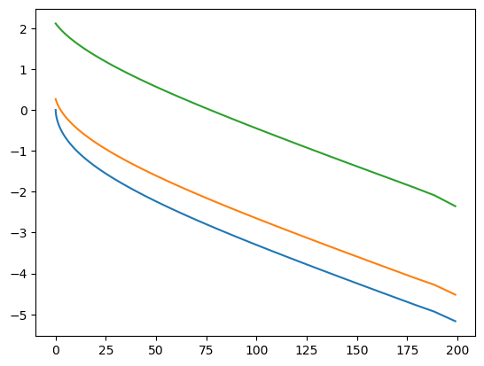

```
1-element Array{PyCall.PyObject,1}:
 PyObject <matplotlib.lines.Line2D object at 0x7f81ccf4aa10>
```

```julia
# net savings
plot(agrid, polall[:, 1] .- agrid)
plot(agrid, polall[:, 10] .- agrid)
plot(agrid, polall[:, 15] .- agrid)
```

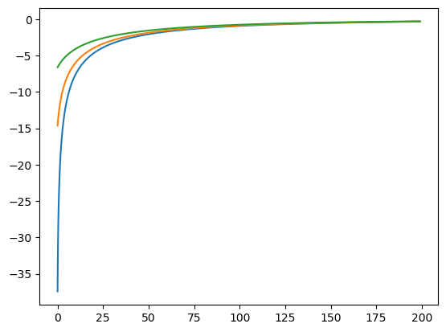

```
1-element Array{PyCall.PyObject,1}:
 PyObject <matplotlib.lines.Line2D object at 0x7f81cce73950>
```

```julia
# value
plot(agrid, vfall[:, 5])
plot(agrid, vfall[:, 10])
plot(agrid, vfall[:, 15])
```

Julia can make use of multiple nodes on a cluster, and pmap will distribute the work across available nodes automatically if you make use of the ClusterManagers package. For example, if you have a Slurm cluster with 2 nodes and 4 tasks per node, the following code should set up and confirm the communication is working.

```julia
# Run without the comments on a Slurm cluster
#=
using Distributed, ClusterManagers
addprocs(SlurmManager(8))
@everywhere function test(x)
    host, pid = gethostname(), getpid()
    "Hello from process $(pid) on host $(host)!"
end
pmap(test, 1:8)
=#
```